# Curso Básico de Jupyter Notebooks

Jupyter Notebooks é uma aplicação web para o desenvolvimento de projetos em ciência de dados, porém suas funcionalidades vão além da interface de programação. Tanto que ela pode ser utilizada para a documentação de projetos como uma alternativa ao Microsoft Word de forma muito mais eficaz.

## Markdown

Por exemplo, um único asterisco *deixa o texto em itálico*, **usamos dois asteriscos** para negrito e três asteriscos para *negrito e itálico*.

# Este é um cabeçalho de nível 1

## Adicionamos ## para cabeçalho nível 2

### Listas

Para criar listas numeradas:

1. Primeiro item
2. Segundo item
   1. Segundo item, subnível 1
      1. Segundo item, subnível 2
3. Terceiro Item

Para criar listas tipo bullet point:

- É muito fácil
- Você não precisa se preocupar com a formatação
- Esta linguagem de programação chama-se Markdown

### Imagens

Também podemos inserir imagens e o Markdown se encarrega de formatar e ajustar a imagem para você:

[figure not shown]

Podemos colocar um link para um arquivo externo em uma imagem:

[figure not shown]

### Linha Horizontal

Basta colocar --- sozinho em uma linha.

### Tabelas

As tabelas também são criadas automaticamente, só que são um *pouquinho* mais complicadas. Copie uma tabela do excel (**o famoso Ctrl+C mesmo**). Agora acesse [este site](https://www.tablesgenerator.com/), clique na aba **Markdown Tables**, então em **File** e **Paste Data**. Copie o resultado e cole logo abaixo.

| ID Cliente | Nome | Cidade | Sexo | Data de Nascimento |
| --- | --- | --- | --- | --- |
| 1 | Ezecrédia | Curitiba | F | 10/04/58 |
| 2 | Filisbina | São Paulo | F | 16/12/76 |
| 3 | Colirinédia | Curitiba | F | 01/01/91 |
| 4 | Uillisberto | Curitiba | M | 04/05/81 |
| 5 | Crodovardo | Porto Alegre | M | 29/08/77 |
| 6 | Vanidisnália | Curitiba | F | 30/03/76 |
| 7 | Filisberto | Porto Alegre | M | 02/10/85 |
| 8 | Jeissikelly | São Paulo | F | 10/11/05 |
| 9 | Esperantina | São Paulo | F | 15/07/88 |
| 10 | Roberverto | São Paulo | M | 10/02/83 |

### Caixas de alerta HTML

O Markdown é uma linguagem de alto nível baseada em HTML, isso significa que comandos HTML também são aceitos e executados. Então agora faremos algo realmente complexo!

Procure no Google por **Bootstrap Alerts**, acesse o primeiro resultado:

[figure not shown]

Copie um exemplo da classe warning e substitua o texto dentro da *div* pelo aviso sobre o uso de tabelas:

**Alerta!** Para a tabela funcionar corretamente é preciso sempre deixar uma linha em branco antes dela!

### Blocos

Este é um novo bloco Markdown, mas perceba que ao executar não percebemos nenhuma diferença ou separador entre os blocos! Os blocos são úteis para organizar e mudar a ordem do conteúdo do seu trabalho sem dor de cabeça.

## Python

Agora vamos aprender a programar. Crie um bloco Python e vire um programador!

```python
print('Olá Mundo!')
```

```
Olá Mundo!
```

Pronto! Você acabou de executar o seu primeiro código!

### Variáveis

Em Python o símbolo **=** SEMPRE deve ser lido como **recebe**.

```python
#Este é um comentário, tudo o que for precedido de # será ignorado no momento da execução

#Atribuindo valor a uma variável
var1 = 123 #var1 recebe 123

#Buscando o valor da variável
var1
```

```
123
```

```python
#Verificando o tipo da variável
type(var1)
```

```
int
```

```python
#Alterando o valor de var1
var1 = 125
var1
```

```
125
```

```python
variavel2 = 123.23
#imprimindo o valor e tipo da variável
print(variavel2, type(variavel2))
```

```
123.23 <class 'float'>
```

```python
#Somando var1 e variavel2
soma = var1 + variavel2
print(soma, type(soma))
```

```
248.23000000000002 <class 'float'>
```

```python
nome = 'Ezecrédia'
#Verificando o tipo de uma variável
print(nome, type(nome))
```

```
Ezecrédia <class 'str'>
```

```python
#criando uma variável do tipo lista
listadecoisas = [2, 'Ezecrédia', 3.5, 'Curitiba']
print(listadecoisas, type(listadecoisas))
```

```
[2, 'Ezecrédia', 3.5, 'Curitiba'] <class 'list'>
```

#### Operadores Aritméticos

Suponha que temos duas variáveis: a = 2 e b =3, então:

| Operador | Descrição | Exemplo | Resultado |
| --- | --- | --- | --- |
| + Adição | Adiciona os valores que estão em qualquer lado do operador | a + b | 5 |
| - Subtração | Subtrai o valor à direita do operador do valor à esquerda | a – b | -1 |
| * Multiplicação | Multiplica os valores que estão em qualquer lado do operador | a * b | 6 |
| / Divisão | Divide valor a esquerda pelo valor a direita | b / a | 1 |
| % Módulo | Divide valor a esquerda pelo valor a direita e retorna o resto | b % a | 1 |
| ** Expoente | Calcula a potência. Valor à esquerda elevado ao valor à direita | a**b | 8 |

```python
a = 2
b =3
a+b
```

```
5
```

```python
a*b
```

```
6
```

```python
a**b
```

```
8
```

```python
b**a
```

```
9
```

### Condicionais

Podemos construir códigos que avaliam **se** uma determinada condição é satisfeita!

```python
#Vamos verificar se soma é maior que 200
soma > 200
```

```
True
```

```python
#Soma é menor que 200?
soma < 200
```

```
False
```

#### Operadores Condicionais

| Operador | Descrição | Exemplo | Resultado |
| --- | --- | --- | --- |
| == | Se os dois valores são iguais, então retorna verdadeiro | (a == b) | falso |
| != | Se os dois valores são diferentes, então retorna verdadeiro | (a != b) | verdadeiro |
| <> | Se os dois valores são diferentes, então retorna verdadeiro | (a <> b) | verdadeiro |
| > | Se o valor da esquerda é maior que o da direita, então retorna verdadeiro. | (a > b) | falso |
| < | Se o valor da esquerda é menor que o da direita, então retorna verdadeiro. | (a < b) | verdadeiro |
| >= | Se o valor da esquerda é maior ou igual ao da direita, então retorna verdadeiro. | (a >= b) | falso |
| <= | Se o valor da esquerda é menor ou igual ao da direita, então retorna verdadeiro. | (a <= b) | verdadeiro |

```python
a == b
```

```
False
```

```python
a < b
```

```
True
```

```python
a = 0
if a == 0:
    print('Nulo')
elif a > 0:
    print('Positivo')
else:
    print('Negativo')
```

```
Nulo
```

### Outras Operações

Outras operações úteis!

```python
# Operador AND
a == 0 and b == 3
```

```
True
```

```python
# Operador OR
a > 3 or b < 0
```

```
False
```

Lembram da variável listadecoisas?

```python
listadecoisas
```

```
[2, 'Ezecrédia', 3.5, 'Curitiba']
```

```python
#Operador IN
'Ezecrédia' in listadecoisas
```

[output not shown]

```
True
```

```python
#Operador NOT
3.5 not in listadecoisas
```

```
False
```

### For Loop

Se quisermos realizar uma mesma operação repetidamente devemos utilizar uma estrutura de recorrência como o **For**:

```python
#Vamos imprimir todos os valores de lista de coisas
for coisa in listadecoisas:
    print(coisa)
```

```
2
Ezecrédia
3.5
Curitiba
```

```python
#vamos imprimir somente se coisa for um texto
for coisa in listadecoisas:
    if type(coisa) == str:
        print(coisa)
```

```
Ezecrédia
Curitiba
```

### Funções

Uma maneira fácil executar uma mesma operação repetidamente é utilizando funções

```python
def quadrado(x):
    return x**2

quadrado(3) #esperamos que a resposta seja 9
```

```
9
```

```python
# e se quisermos elevar ao quadrado todos os números de 0 a 9?
for x in range(10):
    print(quadrado(x))
```

```
0
1
4
9
16
25
36
49
64
81
```

### Juntando Tudo!

```
10.0 m
16.0 m
24.0 m
[0, 1, 2, 3, 4, 5, 6, 7, 8, 9, 10, 11, 12, 13, 14, 15, 16, 17, 18, 19]
[10.0, 16.0, 24.0, 34.0, 46.0, 60.0, 76.0, 94.0, 114.0, 136.0, 160.0, 186.0, 214.0, 244.0, 276.0, 310.0, 346.0, 384.0, 424.0, 466.0]
```

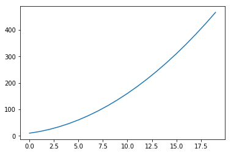

```python
#Vamos falar um pouco de física a função abaixo calcula qual a posição x no tempo t de um objeto em MRUV
def x(t):
    #x = x0 + v0*t + (a*t**2)/2
    #x0 = 10m, v0 = 5m/s, a = 2m/s^2
    x = 10 + 5*t + (2*t**2)/2
    return x

#posição do objeto no tempo 0
print(x(0), 'm')

#posição do objeto no tempo 1
print(x(1), 'm')
print(x(2), 'm')

#podemos plotar um gráfico de x em função de t
import matplotlib.pyplot as plt
%matplotlib inline

t = range(20)
print(list(t))

x = [x(t) for t in t]
print(x)

plt.plot(t, x)
```

### Procv e bases de dados com Python e Pandas

Uma das vantagens de utilizar Python é o fato da linguagem possuir várias bibliotecas para a execução de diferentes tipos de tarefas. Abaixo veremos um exemplo prático de como reproduzir um PROCV!

#### Importando arquivos

```python
#importamos a biblioteca pandas
import pandas as pd

#lendo um arquivo csv com separador do tipo tab
produtos = pd.read_csv('csv/produtos.csv', sep ='\t')
produtos.head() #imprime as 5 primeiras linhas da tabela
```

|  | Unnamed: 0 | Produto | Valor Unitário |
| --- | --- | --- | --- |
| 0 | 0 | NativaSpa Ameixa Negra | 35 |
| 1 | 1 | Malbec | 80 |
| 2 | 2 | Siage | 22 |

```python
#lendo um arquivo excel
pessoas = pd.read_excel('excel/clientes.xlsx')
pessoas.head()
```

|  | ID Cliente | Nome | Cidade | Sexo | Data de Nascimento |
| --- | --- | --- | --- | --- | --- |
| 0 | 1 | Ezecrédia | Curitiba | F | 1958-04-10 |
| 1 | 2 | Filisbina | São Paulo | F | 1976-12-16 |
| 2 | 3 | Colirinédia | Curitiba | F | 1991-01-01 |
| 3 | 4 | Uillisberto | Curitiba | M | 1981-05-04 |
| 4 | 5 | Crodovardo | Porto Alegre | M | 1977-08-29 |

```python
pedidos = pd.read_excel('excel/Pedidos.xlsx')
pedidos.head()
```

|  | Código Pedido | ID Cliente | Produto | Quantidade |
| --- | --- | --- | --- | --- |
| 0 | 125 | 1 | Malbec | 2 |
| 1 | 126 | 3 | NativaSpa Ameixa Negra | 3 |
| 2 | 127 | 3 | Malbec | 1 |
| 3 | 128 | 1 | NativaSpa Ameixa Negra | 1 |
| 4 | 129 | 7 | NativaSpa Ameixa Negra | 2 |

#### PROCV - Left Join

```python
#executa um procv entre a base pedidos e a base produtos.  A chave é a coluna Produto.
# .set_index('Produto') => define a chave
# a.join(b, how= 'left) => executa o procv (todos os elementos de a, elementos correspondentes em b)
consolidada = pedidos.set_index('Produto').join(produtos.set_index('Produto'), how = 'left')
consolidada.head()
```

| Produto | Código Pedido | ID Cliente | Quantidade | Unnamed: 0 | Valor Unitário |
| --- | --- | --- | --- | --- | --- |
| Malbec | 125 | 1 | 2 | 1 | 80 |
| Malbec | 127 | 3 | 1 | 1 | 80 |
| Malbec | 131 | 6 | 10 | 1 | 80 |
| Malbec | 134 | 1 | 1 | 1 | 80 |
| Malbec | 140 | 1 | 1 | 1 | 80 |

```python
#Exclui a coluna Unnamed: 0
consolidada = consolidada.drop('Unnamed: 0', axis =1)
#para excluir uma linha => axis = 0
# para excluir coluna => axis = 1
consolidada.head()
```

| Produto | Código Pedido | ID Cliente | Quantidade | Valor Unitário |
| --- | --- | --- | --- | --- |
| Malbec | 125 | 1 | 2 | 80 |
| Malbec | 127 | 3 | 1 | 80 |
| Malbec | 131 | 6 | 10 | 80 |
| Malbec | 134 | 1 | 1 | 80 |
| Malbec | 140 | 1 | 1 | 80 |

```python
# Reseta o índice da base
consolidada = consolidada.reset_index()

#faz o procv (left join) ente consolidade e pessoas
consolidada = consolidada.set_index('ID Cliente').join(pessoas.set_index('ID Cliente'), how = 'left')
consolidada.head()
```

| ID Cliente | Produto | Código Pedido | Quantidade | Valor Unitário | Nome | Cidade | Sexo | Data de Nascimento |
| --- | --- | --- | --- | --- | --- | --- | --- | --- |
| 1 | Malbec | 125 | 2 | 80 | Ezecrédia | Curitiba | F | 1958-04-10 |
| 1 | Malbec | 134 | 1 | 80 | Ezecrédia | Curitiba | F | 1958-04-10 |
| 1 | Malbec | 140 | 1 | 80 | Ezecrédia | Curitiba | F | 1958-04-10 |
| 1 | NativaSpa Ameixa Negra | 128 | 1 | 35 | Ezecrédia | Curitiba | F | 1958-04-10 |
| 1 | NativaSpa Ameixa Negra | 139 | 1 | 35 | Ezecrédia | Curitiba | F | 1958-04-10 |

```python
#criando uma coluna calculada
consolidada['Valor Total'] = consolidada['Valor Unitário'] * consolidada['Quantidade']
consolidada.head()
```

| ID Cliente | Produto | Código Pedido | Quantidade | Valor Unitário | Nome | Cidade | Sexo | Data de Nascimento | Valor Total |
| --- | --- | --- | --- | --- | --- | --- | --- | --- | --- |
| 1 | Malbec | 125 | 2 | 80 | Ezecrédia | Curitiba | F | 1958-04-10 | 160 |
| 1 | Malbec | 134 | 1 | 80 | Ezecrédia | Curitiba | F | 1958-04-10 | 80 |
| 1 | Malbec | 140 | 1 | 80 | Ezecrédia | Curitiba | F | 1958-04-10 | 80 |
| 1 | NativaSpa Ameixa Negra | 128 | 1 | 35 | Ezecrédia | Curitiba | F | 1958-04-10 | 35 |
| 1 | NativaSpa Ameixa Negra | 139 | 1 | 35 | Ezecrédia | Curitiba | F | 1958-04-10 | 35 |

```python
#retorna o tamanho da tabela (linhas, colunas)
consolidada.shape
```

```
(36, 9)
```

```python
#calcula a soma da coluna Valor Total
total = consolidada['Valor Total'].sum()
print('valor total: ', total)

#calcula a quantidade de pedidos
qtd_pedidos = consolidada['Código Pedido'].count()
print('qtd pedidos: ', qtd_pedidos)

#calcula a soma do valor total de vendas de Malbec
total_malbec = consolidada.query('Produto == "Malbec"')['Valor Total'].sum()
print('valor Malbec: ', total_malbec)
print('% Malbec: ', total_malbec/total) #retorna a participação de Malbec nas vendas
```

```
valor total:  3876
qtd pedidos:  36
valor Malbec:  2080
% Malbec:  0.5366357069143447
```

```python
#Calculando a soma de pedidos por pessoa
pedidos_pessoa = consolidada.groupby('Nome')['Valor Total'].sum().reset_index()
pedidos_pessoa
```

|  | Nome | Valor Total |
| --- | --- | --- |
| 0 | Colirinédia | 309 |
| 1 | Crodovardo | 127 |
| 2 | Esperantina | 280 |
| 3 | Ezecrédia | 741 |
| 4 | Filisberto | 446 |
| 5 | Filisbina | 495 |
| 6 | Roberverto | 289 |
| 7 | Uillisberto | 124 |
| 8 | Vanidisnália | 1065 |

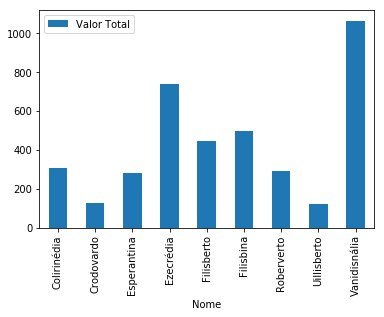

```python
#plotando um gráfico de barras
pedidos_pessoa.plot.bar(pedidos_pessoa['Nome'])
```

```python
#Calculando a soma de Malbec por pessoa
consolidada.query('Produto == "Malbec"').groupby('Nome')['Valor Total'].sum()
```

```
Nome
Colirinédia     160
Ezecrédia       320
Filisberto      240
Filisbina       320
Uillisberto      80
Vanidisnália    960
Name: Valor Total, dtype: int64
```

```python
#Salva a base consolidade em excel
consolidada.to_excel('bases//base_consolidada.xlsx')

#Salva a base consolidade em csv
consolidada.to_csv('bases//base_consolidada.csv')
```

## Como aprender mais?

www.google.com